# RETRASCORE con regiones AIS

Derivación 2015-2019 y validación temporal 2020-2025

2026-10-05

# 1 Diseño del análisis

Se reconstruyen las variables candidatas del estudio RETRASCORE directamente desde el nuevo CSV. Las seis variables `mais1`–`mais6` no se utilizan. En su lugar se calcula el AIS máximo de cada una de las nueve regiones anatómicas a partir de `lesion_X_region_ais` y `lesion_X_gravedad`; cada región entra en el modelo como lesión grave (`AIS >= 3`), siguiendo la dicotomización anatómica empleada en el análisis previo.

El modelo completo se ajusta únicamente en 2015–2019. A continuación se aplica selección stepwise bidireccional por AIC, se reajusta la regresión logística en la misma cohorte y se crean puntos enteros mediante `round(2 x beta)`. Los puntos y la ecuación que convierte la suma en probabilidad quedan fijados antes de evaluar 2020–2025.

# 2 Carga del CSV y reconstrucción de variables

```r
if (!file.exists(archivo_entrada)) {
  stop("No se encuentra ", archivo_entrada, ".")
}

# Se lee todo como texto para no alterar identificadores ni códigos.
df <- read.csv2(
  archivo_entrada,
  stringsAsFactors = FALSE,
  check.names = FALSE,
  colClasses = "character",
  na.strings = NULL
)

limpiar_texto <- function(x) {
  x <- tolower(trimws(as.character(x)))
  x[x %in% c("", "na", "nas")] <- NA_character_
  x
}

convertir_numero <- function(x) {
  x <- trimws(as.character(x))
  x[x %in% c("", "NA", "NAS")] <- NA_character_
  suppressWarnings(as.numeric(gsub(",", ".", x)))
}

convertir_fecha <- function(x) {
  x <- trimws(as.character(x))
  x[x %in% c("", "NA", "NAS")] <- NA_character_
  resultado <- as.Date(rep(NA_character_, length(x)))
  for (formato in c("%d/%m/%Y", "%Y-%m-%d", "%d-%m-%Y")) {
    pendiente <- is.na(resultado) & !is.na(x)
    resultado[pendiente] <- as.Date(x[pendiente], format = formato)
  }
  resultado
}

columnas_necesarias <- c(
  "historia", "registro", "hospital", "fecha_trauma", "fecha_alta_uci",
  "fecha_alta_hospital", "fecha_exitus", "evolucion_uci",
  "evolucion_hospitalaria", "genero", "edad", "antiagregado",
  "dicumarinicos", "acod", "atencion_prehospitalaria",
  "iot_prehospitalaria", "tipo_trauma", "mecanismo", "intencionalidad",
  "pupilas_ingreso", "gcs_total_introducido", "situacion_hemodinamica",
  "adrs", "coagulopatia", "vmec_dico", "hemorragia_masiva"
)
faltan_columnas <- setdiff(columnas_necesarias, names(df))
if (length(faltan_columnas)) {
  stop("Faltan columnas necesarias: ", paste(faltan_columnas, collapse = ", "))
}

fecha_trauma <- convertir_fecha(df$fecha_trauma)
fecha_alta_uci <- convertir_fecha(df$fecha_alta_uci)
fecha_alta_hospital <- convertir_fecha(df$fecha_alta_hospital)
fecha_exitus <- convertir_fecha(df$fecha_exitus)
anio_trauma <- as.integer(format(fecha_trauma, "%Y"))

evolucion_uci <- limpiar_texto(df$evolucion_uci)
evolucion_hospital <- limpiar_texto(df$evolucion_hospitalaria)
muerte_uci <- evolucion_uci %in% c("exitus", "exitus y donacion")
muerte_hospital <- evolucion_hospital %in% c("exitus", "exitus y donacion")

mortalidad_intrahospitalaria <- case_when(
  muerte_uci | muerte_hospital ~ 1L,
  evolucion_hospital == "alta" ~ 0L,
  TRUE ~ NA_integer_
)

fecha_muerte <- as.Date(rep(NA_character_, nrow(df)))
fecha_muerte[muerte_uci] <- fecha_alta_uci[muerte_uci]
fecha_muerte[muerte_hospital] <- fecha_alta_hospital[muerte_hospital]
usar_fecha_exitus <- mortalidad_intrahospitalaria == 1L &
  is.na(fecha_muerte) & !is.na(fecha_exitus)
usar_fecha_exitus[is.na(usar_fecha_exitus)] <- FALSE
fecha_muerte[usar_fecha_exitus] <- fecha_exitus[usar_fecha_exitus]

dias_hasta_muerte <- as.numeric(fecha_muerte - fecha_trauma)
fecha_muerte_valida <- !is.na(dias_hasta_muerte) & dias_hasta_muerte >= 0
mortalidad_30d <- case_when(
  mortalidad_intrahospitalaria == 0L ~ 0L,
  mortalidad_intrahospitalaria == 1L &
    fecha_muerte_valida & dias_hasta_muerte <= 30 ~ 1L,
  mortalidad_intrahospitalaria == 1L &
    fecha_muerte_valida & dias_hasta_muerte > 30 ~ 0L,
  TRUE ~ NA_integer_
)

genero <- limpiar_texto(df$genero)
genero_masculino <- case_when(
  genero == "masculino" ~ 1L,
  genero == "femenino" ~ 0L,
  TRUE ~ NA_integer_
)

edad <- convertir_numero(df$edad)
edad_categoria <- cut(
  edad,
  breaks = c(-Inf, 49, 65, 75, Inf),
  labels = c("<50", "50-65", "66-75", ">75"),
  right = TRUE
)

antiagregado <- limpiar_texto(df$antiagregado)
dicumarinicos <- limpiar_texto(df$dicumarinicos)
acod <- limpiar_texto(df$acod)
precoag <- case_when(
  antiagregado == "si" | dicumarinicos == "si" | acod == "si" ~ 1L,
  antiagregado == "no" & dicumarinicos == "no" & acod == "no" ~ 0L,
  TRUE ~ NA_integer_
)

atencion_ph <- limpiar_texto(df$atencion_prehospitalaria)
atencion_prehospitalaria_medica <- case_when(
  atencion_ph %in% c("uvi movil", "helicoptero") ~ 1L,
  atencion_ph %in% c(
    "no medicalizada", "sin atencion prehospitalaria",
    "soporte vital enfermeria"
  ) ~ 0L,
  TRUE ~ NA_integer_
)

iot_ph <- limpiar_texto(df$iot_prehospitalaria)
iot_prehospitalaria <- case_when(
  iot_ph %in% c("si", "si, con empleo de dispositivos de apoyo") ~ 1L,
  iot_ph == "no" ~ 0L,
  TRUE ~ NA_integer_
)

tipo_trauma <- limpiar_texto(df$tipo_trauma)
trauma_penetrante <- case_when(
  tipo_trauma == "penetrante" ~ 1L,
  tipo_trauma == "contuso" ~ 0L,
  TRUE ~ NA_integer_
)

mecanismo <- limpiar_texto(df$mecanismo)
mecanismo[mecanismo %in% c("otro", "otros", "desconocido")] <-
  "otros/desconocido"
intencionalidad <- limpiar_texto(df$intencionalidad)
mecanismo_alto_riesgo <- case_when(
  mecanismo %in% c(
    "arma de fuego", "atropello", "caida accidental", "otros/desconocido"
  ) ~ 1L,
  mecanismo == "precipitacion" &
    intencionalidad == "intencionado : autolisis" ~ 1L,
  !is.na(mecanismo) & mecanismo != "precipitacion" ~ 0L,
  mecanismo == "precipitacion" & !is.na(intencionalidad) ~ 0L,
  TRUE ~ NA_integer_
)

pupilas_texto <- limpiar_texto(df$pupilas_ingreso)
pupilas <- factor(
  case_when(
    pupilas_texto == "sin alteraciones" ~ "normal",
    pupilas_texto == "midriasis unilateral" ~ "midriasis unilateral",
    pupilas_texto == "midriasis bilatera" ~ "midriasis bilateral",
    pupilas_texto == "midriasis bilateral" ~ "midriasis bilateral",
    TRUE ~ NA_character_
  ),
  levels = c("normal", "midriasis unilateral", "midriasis bilateral")
)

gcs <- convertir_numero(df$gcs_total_introducido)
gcs_menor_igual_8 <- ifelse(is.na(gcs), NA_integer_, as.integer(gcs <= 8))

hemodinamica <- limpiar_texto(df$situacion_hemodinamica)
fallo_hemodinamico <- case_when(
  hemodinamica %in% c("shock", "shock refractario") ~ 1L,
  hemodinamica %in% c("estable", "inestable remonta con volumen") ~ 0L,
  TRUE ~ NA_integer_
)

respiratorio <- limpiar_texto(df$adrs)
fallo_respiratorio <- case_when(
  respiratorio %in% c("<100", "101-200") ~ 1L,
  respiratorio %in% c("no", "201 -300", "> 300") ~ 0L,
  TRUE ~ NA_integer_
)

coagulopatia_texto <- limpiar_texto(df$coagulopatia)
coagulopatia_24h <- case_when(
  coagulopatia_texto == "si" ~ 1L,
  coagulopatia_texto == "no" ~ 0L,
  TRUE ~ NA_integer_
)

vmec <- limpiar_texto(df$vmec_dico)
ventilacion_mecanica <- case_when(
  vmec == "si" ~ 1L,
  vmec == "no" ~ 0L,
  TRUE ~ NA_integer_
)

hemorragia <- limpiar_texto(df$hemorragia_masiva)
hemorragia_masiva <- case_when(
  hemorragia == "si" ~ 1L,
  hemorragia == "no" ~ 0L,
  TRUE ~ NA_integer_
)
```

# 3 AIS máximo por las nueve regiones

```r
columnas_region <- grep(
  "^lesion_[0-9]+_region_ais$", names(df), value = TRUE
)
indices_region <- as.integer(sub(
  "^lesion_([0-9]+)_region_ais$", "\\1", columnas_region
))
columnas_region <- columnas_region[order(indices_region)]
columnas_gravedad <- sub("_region_ais$", "_gravedad", columnas_region)

if (length(columnas_region) != 32L ||
    any(!columnas_gravedad %in% names(df))) {
  stop("No se han encontrado las 32 parejas región/gravedad esperadas.")
}

matriz_region <- sapply(df[columnas_region], convertir_numero)
matriz_gravedad <- sapply(df[columnas_gravedad], convertir_numero)
matriz_region[!(matriz_region %in% 1:9)] <- NA_real_
matriz_gravedad[!(matriz_gravedad %in% 1:6)] <- NA_real_

nombres_regiones <- c(
  "craneo", "cara", "cuello", "torax", "abdomen",
  "columna_vertebral", "extremidades_superiores",
  "extremidades_inferiores", "piel_partes_blandas"
)
etiquetas_regiones <- c(
  "Craneo", "Cara", "Cuello", "Torax", "Abdomen",
  "Columna vertebral", "Extremidades superiores",
  "Extremidades inferiores", "Piel y partes blandas"
)

ais_regional <- matrix(
  0, nrow = nrow(df), ncol = 9,
  dimnames = list(NULL, paste0("ais_", nombres_regiones))
)
gravedad_incompleta <- matrix(FALSE, nrow = nrow(df), ncol = 9)

for (codigo_region in 1:9) {
  pertenece <- matriz_region == codigo_region
  pertenece[is.na(pertenece)] <- FALSE
  hay_region <- rowSums(pertenece) > 0
  hay_gravedad_ausente <- rowSums(pertenece & is.na(matriz_gravedad)) > 0

  maximo <- rep(0, nrow(df))
  for (j in seq_len(ncol(matriz_region))) {
    valor <- ifelse(pertenece[, j], matriz_gravedad[, j], 0)
    valor[is.na(valor)] <- 0
    maximo <- pmax(maximo, valor)
  }
  maximo[hay_region & hay_gravedad_ausente] <- NA_real_
  ais_regional[, codigo_region] <- maximo
  gravedad_incompleta[, codigo_region] <- hay_region & hay_gravedad_ausente
}

ais_regional <- as.data.frame(ais_regional)
ais_grave_regional <- as.data.frame(lapply(
  ais_regional,
  function(x) ifelse(is.na(x), NA_integer_, as.integer(x >= 3))
))
names(ais_grave_regional) <- paste0("ais3_", nombres_regiones)

resumen_ais_regional <- data.frame(
  codigo = 1:9,
  region = etiquetas_regiones,
  pacientes_con_lesion = vapply(
    ais_regional, function(x) sum(x > 0, na.rm = TRUE), numeric(1)
  ),
  pacientes_con_AIS_3_o_mas = vapply(
    ais_regional, function(x) sum(x >= 3, na.rm = TRUE), numeric(1)
  ),
  pacientes_con_gravedad_incompleta = colSums(gravedad_incompleta),
  row.names = NULL
)

utils::write.csv(
  resumen_ais_regional,
  file.path(directorio_salida, "resumen_regiones_ais.csv"),
  row.names = FALSE,
  fileEncoding = "UTF-8"
)
knitr::kable(
  resumen_ais_regional,
  caption = "Reconstrucción del AIS máximo por región"
)
```

Reconstrucción del AIS máximo por región

| codigo | region | pacientes_con_lesion | pacientes_con_AIS_3_o_mas | pacientes_con_gravedad_incompleta |
| --- | --- | --- | --- | --- |
| 1 | Craneo | 10068 | 7704 | 0 |
| 2 | Cara | 4068 | 568 | 0 |
| 3 | Cuello | 371 | 151 | 0 |
| 4 | Torax | 9498 | 7303 | 0 |
| 5 | Abdomen | 4047 | 2475 | 0 |
| 6 | Columna vertebral | 5392 | 1998 | 0 |
| 7 | Extremidades superiores | 5028 | 530 | 1 |
| 8 | Extremidades inferiores | 5671 | 3434 | 0 |
| 9 | Piel y partes blandas | 901 | 158 | 0 |

# 4 Cohorte analítica y variables candidatas

```r
cohorte <- data.frame(
  id_fila = seq_len(nrow(df)),
  historia = df$historia,
  registro = df$registro,
  hospital = df$hospital,
  anio_trauma = anio_trauma,
  mortalidad_intrahospitalaria = mortalidad_intrahospitalaria,
  mortalidad_30d = mortalidad_30d,
  genero_masculino = genero_masculino,
  edad_categoria = factor(
    edad_categoria, levels = c("<50", "50-65", "66-75", ">75")
  ),
  precoag = precoag,
  atencion_prehospitalaria_medica = atencion_prehospitalaria_medica,
  iot_prehospitalaria = iot_prehospitalaria,
  trauma_penetrante = trauma_penetrante,
  mecanismo_alto_riesgo = mecanismo_alto_riesgo,
  pupilas = pupilas,
  gcs_menor_igual_8 = gcs_menor_igual_8,
  ais_grave_regional,
  fallo_hemodinamico = fallo_hemodinamico,
  fallo_respiratorio = fallo_respiratorio,
  coagulopatia_24h = coagulopatia_24h,
  ventilacion_mecanica = ventilacion_mecanica,
  hemorragia_masiva = hemorragia_masiva,
  check.names = FALSE
)

# Las variables no anatómicas son las mismas candidatas del estudio. Las seis
# variables MAIS se sustituyen por las nueve regiones reconstruidas.
variables_candidatas <- c(
  "edad_categoria", "genero_masculino", "precoag",
  "atencion_prehospitalaria_medica", "iot_prehospitalaria",
  "trauma_penetrante", "mecanismo_alto_riesgo", "pupilas",
  "gcs_menor_igual_8",
  names(ais_grave_regional),
  "fallo_hemodinamico", "fallo_respiratorio", "coagulopatia_24h",
  "ventilacion_mecanica", "hemorragia_masiva"
)

cohorte_elegible <- cohorte %>%
  filter(
    !is.na(mortalidad_intrahospitalaria),
    !is.na(anio_trauma),
    anio_trauma >= 2015,
    anio_trauma <= 2025
  ) %>%
  mutate(
    id_analisis = row_number(),
    periodo = factor(
      ifelse(anio_trauma <= 2019, "Derivacion 2015-2019", "Validacion 2020-2025"),
      levels = c("Derivacion 2015-2019", "Validacion 2020-2025")
    )
  )

derivacion_total <- cohorte_elegible %>%
  filter(periodo == "Derivacion 2015-2019")
validacion_total <- cohorte_elegible %>%
  filter(periodo == "Validacion 2020-2025")

variables_modelo_completo <- c("mortalidad_30d", variables_candidatas)
derivacion <- derivacion_total[
  complete.cases(
    derivacion_total[, variables_modelo_completo, drop = FALSE]
  ), , drop = FALSE
]

if (!nrow(derivacion) || length(unique(derivacion$mortalidad_30d)) != 2L) {
  stop("La cohorte de derivación no permite ajustar el modelo.")
}

flujo_cohortes <- data.frame(
  cohorte = c("Derivacion 2015-2019", "Validacion 2020-2025"),
  elegibles = c(nrow(derivacion_total), nrow(validacion_total)),
  outcome_30d_conocido = c(
    sum(!is.na(derivacion_total$mortalidad_30d)),
    sum(!is.na(validacion_total$mortalidad_30d))
  ),
  completos_para_todas_las_candidatas = c(
    sum(complete.cases(
      derivacion_total[, variables_modelo_completo, drop = FALSE]
    )),
    sum(complete.cases(
      validacion_total[, variables_modelo_completo, drop = FALSE]
    ))
  )
)

knitr::kable(
  data.frame(variable_candidata = variables_candidatas),
  caption = paste(length(variables_candidatas), "variables candidatas")
)
```

23 variables candidatas

| variable_candidata |
| --- |
| edad_categoria |
| genero_masculino |
| precoag |
| atencion_prehospitalaria_medica |
| iot_prehospitalaria |
| trauma_penetrante |
| mecanismo_alto_riesgo |
| pupilas |
| gcs_menor_igual_8 |
| ais3_craneo |
| ais3_cara |
| ais3_cuello |
| ais3_torax |
| ais3_abdomen |
| ais3_columna_vertebral |
| ais3_extremidades_superiores |
| ais3_extremidades_inferiores |
| ais3_piel_partes_blandas |
| fallo_hemodinamico |
| fallo_respiratorio |
| coagulopatia_24h |
| ventilacion_mecanica |
| hemorragia_masiva |

```r
knitr::kable(flujo_cohortes, caption = "Flujo de las cohortes")
```

Flujo de las cohortes

| cohorte | elegibles | outcome_30d_conocido | completos_para_todas_las_candidatas |
| --- | --- | --- | --- |
| Derivacion 2015-2019 | 8821 | 8814 | 7935 |
| Validacion 2020-2025 | 9095 | 9092 | 8172 |

# 5 Selección stepwise y regresión logística

```r
formula_completa <- reformulate(
  variables_candidatas, response = "mortalidad_30d"
)
modelo_completo <- glm(
  formula_completa,
  data = derivacion,
  family = binomial(link = "logit"),
  na.action = na.fail
)
if (!modelo_completo$converged || anyNA(coef(modelo_completo))) {
  stop("El modelo completo no converge o contiene coeficientes no estimables.")
}

modelo_stepwise <- MASS::stepAIC(
  modelo_completo,
  direction = "both",
  trace = FALSE
)
if (!modelo_stepwise$converged || anyNA(coef(modelo_stepwise))) {
  stop("El modelo stepwise no converge o contiene coeficientes no estimables.")
}

variables_seleccionadas <- attr(terms(modelo_stepwise), "term.labels")
if (!length(variables_seleccionadas)) {
  stop("La selección produjo un modelo con solo intercepto.")
}

ruta_stepwise <- modelo_stepwise$anova
names(ruta_stepwise) <- make.names(names(ruta_stepwise), unique = TRUE)
utils::write.csv(
  ruta_stepwise,
  file.path(directorio_salida, "ruta_stepwise.csv"),
  row.names = FALSE,
  fileEncoding = "UTF-8"
)

resumen_seleccion <- data.frame(
  N_derivacion = nrow(derivacion),
  muertes_30d = sum(derivacion$mortalidad_30d),
  variables_candidatas = length(variables_candidatas),
  variables_seleccionadas = length(variables_seleccionadas),
  AIC_modelo_completo = AIC(modelo_completo),
  AIC_modelo_stepwise = AIC(modelo_stepwise)
)

coeficientes <- summary(modelo_stepwise)$coefficients
tabla_coeficientes <- data.frame(
  termino = rownames(coeficientes),
  beta = coeficientes[, "Estimate"],
  error_estandar = coeficientes[, "Std. Error"],
  p = coeficientes[, "Pr(>|z|)"],
  OR = exp(coeficientes[, "Estimate"]),
  IC95_inferior = exp(
    coeficientes[, "Estimate"] - 1.96 * coeficientes[, "Std. Error"]
  ),
  IC95_superior = exp(
    coeficientes[, "Estimate"] + 1.96 * coeficientes[, "Std. Error"]
  ),
  row.names = NULL
)

utils::write.csv(
  tabla_coeficientes,
  file.path(directorio_salida, "coeficientes_regresion_logistica.csv"),
  row.names = FALSE,
  fileEncoding = "UTF-8"
)

knitr::kable(resumen_seleccion, digits = 3, caption = "Resumen de la selección")
```

Resumen de la selección

| N_derivacion | muertes_30d | variables_candidatas | variables_seleccionadas | AIC_modelo_completo | AIC_modelo_stepwise |
| --- | --- | --- | --- | --- | --- |
| 7935 | 1035 | 23 | 19 | 3380.496 | 3373.425 |

```r
knitr::kable(
  data.frame(variable_seleccionada = variables_seleccionadas),
  caption = "Variables retenidas por stepwise bidireccional"
)
```

Variables retenidas por stepwise bidireccional

| variable_seleccionada |
| --- |
| edad_categoria |
| genero_masculino |
| precoag |
| iot_prehospitalaria |
| mecanismo_alto_riesgo |
| pupilas |
| gcs_menor_igual_8 |
| ais3_craneo |
| ais3_cara |
| ais3_cuello |
| ais3_torax |
| ais3_columna_vertebral |
| ais3_extremidades_inferiores |
| ais3_piel_partes_blandas |
| fallo_hemodinamico |
| fallo_respiratorio |
| coagulopatia_24h |
| ventilacion_mecanica |
| hemorragia_masiva |

```r
knitr::kable(ruta_stepwise, digits = 3, caption = "Ruta de selección por AIC")
```

Ruta de selección por AIC

| Step | Df | Deviance | Resid..Df | Resid..Dev | AIC |
| --- | --- | --- | --- | --- | --- |
|  | NA | NA | 7908 | 3326.496 | 3380.496 |
| - trauma_penetrante | 1 | 0.013 | 7909 | 3326.509 | 3378.509 |
| - ais3_extremidades_superiores | 1 | 0.172 | 7910 | 3326.681 | 3376.681 |
| - atencion_prehospitalaria_medica | 1 | 0.216 | 7911 | 3326.897 | 3374.897 |
| - ais3_abdomen | 1 | 0.528 | 7912 | 3327.425 | 3373.425 |

```r
knitr::kable(
  tabla_coeficientes,
  digits = 4,
  caption = "Regresión logística final ajustada en 2015-2019"
)
```

Regresión logística final ajustada en 2015-2019

| termino | beta | error_estandar | p | OR | IC95_inferior | IC95_superior |
| --- | --- | --- | --- | --- | --- | --- |
| (Intercept) | -5.9284 | 0.2012 | 0.0000 | 0.0027 | 0.0018 | 0.0040 |
| edad_categoria50-65 | 0.9426 | 0.1304 | 0.0000 | 2.5667 | 1.9878 | 3.3143 |
| edad_categoria66-75 | 1.6636 | 0.1520 | 0.0000 | 5.2783 | 3.9185 | 7.1099 |
| edad_categoria>75 | 2.5405 | 0.1528 | 0.0000 | 12.6863 | 9.4034 | 17.1153 |
| genero_masculino | 0.2223 | 0.1072 | 0.0380 | 1.2490 | 1.0123 | 1.5409 |
| precoag | 0.4325 | 0.1175 | 0.0002 | 1.5412 | 1.2242 | 1.9402 |
| iot_prehospitalaria | 0.2570 | 0.1191 | 0.0309 | 1.2930 | 1.0239 | 1.6329 |
| mecanismo_alto_riesgo | 0.6202 | 0.1050 | 0.0000 | 1.8594 | 1.5134 | 2.2844 |
| pupilasmidriasis unilateral | 1.2154 | 0.1266 | 0.0000 | 3.3716 | 2.6309 | 4.3207 |
| pupilasmidriasis bilateral | 3.2990 | 0.1899 | 0.0000 | 27.0854 | 18.6666 | 39.3011 |
| gcs_menor_igual_8 | 1.1040 | 0.1252 | 0.0000 | 3.0163 | 2.3601 | 3.8549 |
| ais3_craneo | 0.7604 | 0.1172 | 0.0000 | 2.1390 | 1.7001 | 2.6913 |
| ais3_cara | -0.5413 | 0.2650 | 0.0411 | 0.5820 | 0.3462 | 0.9783 |
| ais3_cuello | 1.4035 | 0.4231 | 0.0009 | 4.0693 | 1.7757 | 9.3252 |
| ais3_torax | -0.2419 | 0.1091 | 0.0267 | 0.7852 | 0.6340 | 0.9724 |
| ais3_columna_vertebral | 0.6820 | 0.1543 | 0.0000 | 1.9778 | 1.4616 | 2.6764 |
| ais3_extremidades_inferiores | -0.2105 | 0.1405 | 0.1341 | 0.8102 | 0.6152 | 1.0671 |
| ais3_piel_partes_blandas | 1.0863 | 0.4366 | 0.0128 | 2.9631 | 1.2592 | 6.9726 |
| fallo_hemodinamico | 1.0637 | 0.1130 | 0.0000 | 2.8972 | 2.3216 | 3.6156 |
| fallo_respiratorio | 0.6610 | 0.1207 | 0.0000 | 1.9367 | 1.5288 | 2.4536 |
| coagulopatia_24h | 0.6620 | 0.1248 | 0.0000 | 1.9387 | 1.5181 | 2.4757 |
| ventilacion_mecanica | 0.4648 | 0.1205 | 0.0001 | 1.5917 | 1.2570 | 2.0156 |
| hemorragia_masiva | 0.7568 | 0.1672 | 0.0000 | 2.1314 | 1.5359 | 2.9578 |

# 6 Creación de la puntuación RETRASCORE

```r
redondear_entero <- function(x) sign(x) * floor(abs(x) + 0.5)

betas <- coef(modelo_stepwise)[-1]
puntos <- setNames(
  as.integer(redondear_entero(2 * betas)),
  names(betas)
)

tabla_puntos <- data.frame(
  termino = names(betas),
  beta = as.numeric(betas),
  beta_por_2 = 2 * as.numeric(betas),
  puntos_retrascore = as.integer(puntos),
  row.names = NULL
)

filas_referencia <- lapply(names(modelo_stepwise$xlevels), function(variable) {
  data.frame(
    termino = paste0(variable, modelo_stepwise$xlevels[[variable]][1],
                     " (referencia)"),
    beta = 0,
    beta_por_2 = 0,
    puntos_retrascore = 0L
  )
})
tabla_puntos_mostrar <- if (length(filas_referencia)) {
  rbind(tabla_puntos, do.call(rbind, filas_referencia))
} else tabla_puntos

formula_puntuacion <- reformulate(variables_seleccionadas)
calcular_puntuacion <- function(datos) {
  matriz <- model.matrix(formula_puntuacion, data = datos)[, -1, drop = FALSE]
  columnas_faltantes <- setdiff(names(puntos), colnames(matriz))
  if (length(columnas_faltantes)) {
    stop("Faltan términos para calcular la puntuación: ",
         paste(columnas_faltantes, collapse = ", "))
  }
  matriz <- matriz[, names(puntos), drop = FALSE]
  as.integer(drop(matriz %*% puntos))
}

disponible_puntuacion <- complete.cases(
  cohorte_elegible[, variables_seleccionadas, drop = FALSE]
)
cohorte_elegible$retrascore_regional <- NA_integer_
cohorte_elegible$retrascore_regional[disponible_puntuacion] <-
  calcular_puntuacion(
    cohorte_elegible[disponible_puntuacion, , drop = FALSE]
  )

# La relación puntos-probabilidad se estima solo en los casos de derivación
# utilizados por la regresión y después queda fijada.
derivacion$retrascore_regional <- calcular_puntuacion(derivacion)
modelo_probabilidad_puntos <- glm(
  mortalidad_30d ~ retrascore_regional,
  data = derivacion,
  family = binomial(link = "logit")
)
if (!modelo_probabilidad_puntos$converged) {
  stop("No converge la ecuación que convierte puntos en probabilidad.")
}

cohorte_elegible$probabilidad_mortalidad <- NA_real_
cohorte_elegible$probabilidad_mortalidad[disponible_puntuacion] <- predict(
  modelo_probabilidad_puntos,
  newdata = data.frame(
    retrascore_regional = cohorte_elegible$retrascore_regional[
      disponible_puntuacion
    ]
  ),
  type = "response"
)

utils::write.csv(
  tabla_puntos_mostrar,
  file.path(directorio_salida, "puntos_retrascore_regiones_ais.csv"),
  row.names = FALSE,
  fileEncoding = "UTF-8"
)

ecuacion_puntuacion <- data.frame(
  componente = c("Intercepto", "Coeficiente por punto"),
  estimacion = unname(coef(modelo_probabilidad_puntos))
)

knitr::kable(
  tabla_puntos_mostrar,
  digits = c(0, 4, 4, 0),
  caption = "Puntos derivados en 2015-2019 y fijados para ambas cohortes"
)
```

Puntos derivados en 2015-2019 y fijados para ambas cohortes

| termino | beta | beta_por_2 | puntos_retrascore |
| --- | --- | --- | --- |
| edad_categoria50-65 | 0.9426 | 1.8853 | 2 |
| edad_categoria66-75 | 1.6636 | 3.3272 | 3 |
| edad_categoria>75 | 2.5405 | 5.0810 | 5 |
| genero_masculino | 0.2223 | 0.4446 | 0 |
| precoag | 0.4325 | 0.8651 | 1 |
| iot_prehospitalaria | 0.2570 | 0.5139 | 1 |
| mecanismo_alto_riesgo | 0.6202 | 1.2405 | 1 |
| pupilasmidriasis unilateral | 1.2154 | 2.4308 | 2 |
| pupilasmidriasis bilateral | 3.2990 | 6.5980 | 7 |
| gcs_menor_igual_8 | 1.1040 | 2.2081 | 2 |
| ais3_craneo | 0.7604 | 1.5207 | 2 |
| ais3_cara | -0.5413 | -1.0825 | -1 |
| ais3_cuello | 1.4035 | 2.8069 | 3 |
| ais3_torax | -0.2419 | -0.4837 | 0 |
| ais3_columna_vertebral | 0.6820 | 1.3640 | 1 |
| ais3_extremidades_inferiores | -0.2105 | -0.4210 | 0 |
| ais3_piel_partes_blandas | 1.0863 | 2.1725 | 2 |
| fallo_hemodinamico | 1.0637 | 2.1275 | 2 |
| fallo_respiratorio | 0.6610 | 1.3220 | 1 |
| coagulopatia_24h | 0.6620 | 1.3240 | 1 |
| ventilacion_mecanica | 0.4648 | 0.9296 | 1 |
| hemorragia_masiva | 0.7568 | 1.5136 | 2 |
| edad_categoria<50 (referencia) | 0.0000 | 0.0000 | 0 |
| pupilasnormal (referencia) | 0.0000 | 0.0000 | 0 |

```r
knitr::kable(
  ecuacion_puntuacion,
  digits = 5,
  caption = "Ecuación de mortalidad estimada en 2015-2019"
)
```

Ecuación de mortalidad estimada en 2015-2019

| componente | estimacion |
| --- | --- |
| Intercepto | -5.80153 |
| Coeficiente por punto | 0.48673 |

Para una puntuación total (S), la probabilidad de mortalidad a 30 días es:

$$P(Y=1) = \frac{1}{1 + \exp[-(a+bS)]}.$$

# 7 Validación temporal en 2020-2025

```r
evaluacion_derivacion <- cohorte_elegible %>%
  filter(
    id_analisis %in% derivacion$id_analisis,
    !is.na(mortalidad_30d),
    !is.na(probabilidad_mortalidad)
  )
evaluacion_validacion <- cohorte_elegible %>%
  filter(
    periodo == "Validacion 2020-2025",
    !is.na(mortalidad_30d),
    !is.na(probabilidad_mortalidad)
  )

evaluar_modelo <- function(datos, nombre_cohorte) {
  outcome <- datos$mortalidad_30d
  probabilidad <- datos$probabilidad_mortalidad
  roc <- pROC::roc(
    outcome, probabilidad,
    levels = c(0, 1), direction = "<", quiet = TRUE
  )
  ic_auc <- as.numeric(pROC::ci.auc(roc, method = "delong"))
  lp <- qlogis(pmin(pmax(probabilidad, 1e-12), 1 - 1e-12))
  modelo_intercepto <- glm(
    outcome ~ 1, offset = lp, family = binomial(link = "logit")
  )
  modelo_pendiente <- glm(
    outcome ~ lp, family = binomial(link = "logit")
  )
  data.frame(
    cohorte = nombre_cohorte,
    n = length(outcome),
    muertes_30d = sum(outcome),
    mortalidad_observada_pct = 100 * mean(outcome),
    mortalidad_predicha_pct = 100 * mean(probabilidad),
    AUROC = as.numeric(pROC::auc(roc)),
    AUROC_IC95_inferior = ic_auc[1],
    AUROC_IC95_superior = ic_auc[3],
    Brier = mean((outcome - probabilidad)^2),
    intercepto_calibracion = unname(coef(modelo_intercepto)[1]),
    pendiente_calibracion = unname(coef(modelo_pendiente)[2]),
    row.names = NULL
  )
}

metricas <- rbind(
  evaluar_modelo(evaluacion_derivacion, "Derivacion 2015-2019"),
  evaluar_modelo(evaluacion_validacion, "Validacion 2020-2025")
)
metricas_mostrar <- metricas
metricas_mostrar$`AUROC (IC95%)` <- sprintf(
  "%.3f (%.3f-%.3f)",
  metricas_mostrar$AUROC,
  metricas_mostrar$AUROC_IC95_inferior,
  metricas_mostrar$AUROC_IC95_superior
)
metricas_mostrar <- metricas_mostrar[, c(
  "cohorte", "n", "muertes_30d", "mortalidad_observada_pct",
  "mortalidad_predicha_pct", "AUROC (IC95%)", "Brier",
  "intercepto_calibracion", "pendiente_calibracion"
)]

utils::write.csv(
  metricas,
  file.path(directorio_salida, "metricas_derivacion_validacion.csv"),
  row.names = FALSE,
  fileEncoding = "UTF-8"
)
knitr::kable(
  metricas_mostrar,
  digits = c(0, 0, 0, 2, 2, 0, 3, 3, 3),
  caption = "Rendimiento de la puntuación fija en ambas cohortes"
)
```

Rendimiento de la puntuación fija en ambas cohortes

| cohorte | n | muertes_30d | mortalidad_observada_pct | mortalidad_predicha_pct | AUROC (IC95%) | Brier | intercepto_calibracion | pendiente_calibracion |
| --- | --- | --- | --- | --- | --- | --- | --- | --- |
| Derivacion 2015-2019 | 7935 | 1035 | 13.04 | 13.04 | 0.925 (0.918-0.933) | 0.064 | 0.000 | 1.000 |
| Validacion 2020-2025 | 8450 | 1013 | 11.99 | 11.55 | 0.926 (0.919-0.934) | 0.062 | 0.074 | 1.007 |

## 7.1 Mortalidad por puntuación

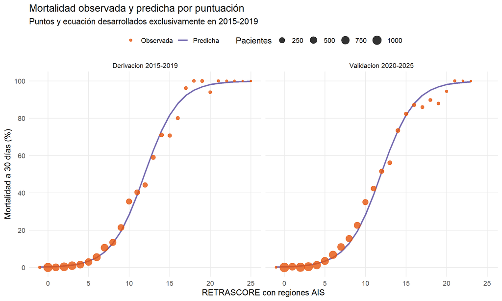

```r
datos_grafico <- bind_rows(
  evaluacion_derivacion %>% mutate(cohorte = "Derivacion 2015-2019"),
  evaluacion_validacion %>% mutate(cohorte = "Validacion 2020-2025")
)

mortalidad_puntuacion <- datos_grafico %>%
  group_by(cohorte, retrascore_regional) %>%
  summarise(
    pacientes = n(),
    muertes = sum(mortalidad_30d),
    mortalidad_observada_pct = 100 * mean(mortalidad_30d),
    mortalidad_predicha_pct = 100 * mean(probabilidad_mortalidad),
    .groups = "drop"
  )

utils::write.csv(
  mortalidad_puntuacion,
  file.path(directorio_salida, "mortalidad_por_puntuacion.csv"),
  row.names = FALSE,
  fileEncoding = "UTF-8"
)

datos_grafico_largo <- rbind(
  data.frame(
    cohorte = mortalidad_puntuacion$cohorte,
    puntuacion = mortalidad_puntuacion$retrascore_regional,
    pacientes = mortalidad_puntuacion$pacientes,
    tipo = "Predicha",
    mortalidad = mortalidad_puntuacion$mortalidad_predicha_pct
  ),
  data.frame(
    cohorte = mortalidad_puntuacion$cohorte,
    puntuacion = mortalidad_puntuacion$retrascore_regional,
    pacientes = mortalidad_puntuacion$pacientes,
    tipo = "Observada",
    mortalidad = mortalidad_puntuacion$mortalidad_observada_pct
  )
)

grafico_puntuacion <- ggplot(
  datos_grafico_largo,
  aes(x = puntuacion, y = mortalidad, colour = tipo)
) +
  geom_line(
    data = subset(datos_grafico_largo, tipo == "Predicha"),
    linewidth = 1
  ) +
  geom_point(
    data = subset(datos_grafico_largo, tipo == "Observada"),
    aes(size = pacientes), alpha = 0.8
  ) +
  facet_wrap(~ cohorte) +
  scale_colour_manual(values = c("Predicha" = "#756BB1", "Observada" = "#E6550D")) +
  scale_y_continuous(limits = c(0, 100), breaks = seq(0, 100, 20)) +
  labs(
    title = "Mortalidad observada y predicha por puntuación",
    subtitle = "Puntos y ecuación desarrollados exclusivamente en 2015-2019",
    x = "RETRASCORE con regiones AIS",
    y = "Mortalidad a 30 días (%)",
    colour = NULL,
    size = "Pacientes"
  ) +
  theme_minimal(base_size = 12) +
  theme(panel.grid.minor = element_blank(), legend.position = "top")

grafico_puntuacion
```

```r
ggsave(
  file.path(directorio_salida, "mortalidad_por_puntuacion.png"),
  grafico_puntuacion,
  width = 11, height = 6.5, dpi = 180
)
```

# 8 Archivos de resultados y modelo reutilizable

```r
puntuaciones_pacientes <- cohorte_elegible %>%
  select(
    id_fila, historia, registro, hospital, anio_trauma,
    cohorte = periodo, mortalidad_30d,
    retrascore_regional, probabilidad_mortalidad
  ) %>%
  mutate(
    puntuacion_disponible = !is.na(retrascore_regional),
    .after = mortalidad_30d
  )

utils::write.csv(
  puntuaciones_pacientes,
  file.path(directorio_salida, "puntuaciones_y_predicciones_pacientes.csv"),
  row.names = FALSE,
  na = "",
  fileEncoding = "UTF-8"
)

paquete_modelo <- list(
  archivo_fuente = archivo_entrada,
  anios_derivacion = 2015:2019,
  anios_validacion = 2020:2025,
  definicion_anatomica = "AIS maximo por region, dicotomizado como AIS >= 3",
  regiones_ais = setNames(1:9, nombres_regiones),
  variables_candidatas = variables_candidatas,
  variables_seleccionadas = variables_seleccionadas,
  formula_completa = formula_completa,
  modelo_completo = modelo_completo,
  ruta_stepwise = ruta_stepwise,
  modelo_logistico = modelo_stepwise,
  puntos = puntos,
  modelo_probabilidad_puntos = modelo_probabilidad_puntos
)
saveRDS(
  paquete_modelo,
  file.path(directorio_salida, "modelo_retrascore_regiones_ais.rds")
)

archivos_guardados <- data.frame(
  archivo = c(
    "resumen_regiones_ais.csv",
    "ruta_stepwise.csv",
    "coeficientes_regresion_logistica.csv",
    "puntos_retrascore_regiones_ais.csv",
    "metricas_derivacion_validacion.csv",
    "mortalidad_por_puntuacion.csv",
    "puntuaciones_y_predicciones_pacientes.csv",
    "mortalidad_por_puntuacion.png",
    "modelo_retrascore_regiones_ais.rds"
  )
)
knitr::kable(archivos_guardados, caption = "Resultados guardados")
```

Resultados guardados

| archivo |
| --- |
| resumen_regiones_ais.csv |
| ruta_stepwise.csv |
| coeficientes_regresion_logistica.csv |
| puntos_retrascore_regiones_ais.csv |
| metricas_derivacion_validacion.csv |
| mortalidad_por_puntuacion.csv |
| puntuaciones_y_predicciones_pacientes.csv |
| mortalidad_por_puntuacion.png |
| modelo_retrascore_regiones_ais.rds |

# 9 Notas de reproducibilidad

- Las nueve regiones AIS se reconstruyen desde las columnas de lesión del CSV; no se utilizan `mais1`–`mais6`.
- Si existe una lesión asignada a una región pero su gravedad está ausente o fuera de 1–6, el AIS regional se conserva como ausente.
- La ausencia de lesiones documentadas en una región se codifica como AIS 0.
- El modelo completo y todos los modelos stepwise utilizan exactamente los mismos casos completos de 2015–2019.
- La cohorte 2020–2025 no interviene en la selección, los coeficientes, los puntos ni la ecuación de probabilidad.
- Los intervalos de confianza posteriores a stepwise son descriptivos y no incorporan la incertidumbre de la selección de variables.

# 10 Fuentes

Serviá L, et al. *Development of a new score for early mortality prediction in trauma ICU patients: RETRASCORE*. Critical Care. 2021;25:420. doi:10.1186/s13054-021-03845-6.

La selección se implementa mediante `MASS::stepAIC()` con dirección bidireccional y criterio AIC.